# Assignment 7: Upwelling Visualization

### Now that we've confirmed our bathymetry is somewhat channel-shaped, we can start looking at model output.

#### Let's look at the following variables from the **history file** through time:

##### - temperature ('temp')

##### - salinity ('salt')

##### - u-velocity ('u')

##### - v-velocity ('v')

##### - vertical velocity ('w')

# #1. Plot the above variables in the same format as this example figure for the start of the Upwelling model.

[figure not shown]

### Be sure to use [distinct colormaps](https://matplotlib.org/cmocean/) when appropriate.

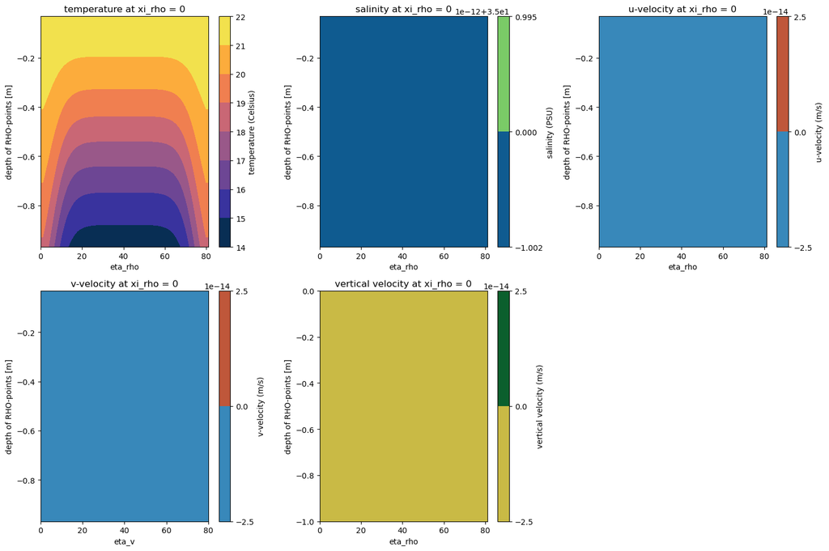

```python
# Let's set some values so we don't have to change them in multiple places
#xi_rho_index  = 0; # Goes from 0 to 42
#time_index    = 0; # Goes from 0 to 20

# Create the figure
#fig = plt.figure(figsize=(15.0, 10.0))

#And add panels to plot in
#axes1 = fig.add_subplot(2, 3, 1)
#axes2 = fig.add_subplot(2, 3, 2)
#axes3 = fig.add_subplot(2, 3, 3)
#axes4 = fig.add_subplot(2, 3, 4)
#axes5 = fig.add_subplot(2, 3, 5)


# Then start adding variables
# Choose the first time step and vertical slice (xi_rho = 0) for all variables
# Set fixed indices for ocean_time and xi_rho
xi_rho_index = 0  # Goes from 0 to 42
time_index = 0    # Goes from 0 to 20

# Create the figure with a 2x3 grid layout
fig = plt.figure(figsize=(15.0, 10.0))

# Define each variable and its properties, including the appropriate dimensions for slicing
variables = {
    'temp': {'name': 'temperature', 'units': 'Celsius', 'cmap': cmo.thermal, 'ax': fig.add_subplot(2, 3, 1), 'isel': {'xi_rho': xi_rho_index, 'ocean_time': time_index}},
    'salt': {'name': 'salinity', 'units': 'PSU', 'cmap': cmo.haline, 'ax': fig.add_subplot(2, 3, 2), 'isel': {'xi_rho': xi_rho_index, 'ocean_time': time_index}},
    'u': {'name': 'u-velocity', 'units': 'm/s', 'cmap': cmo.balance, 'ax': fig.add_subplot(2, 3, 3), 'isel': {'xi_u': xi_rho_index, 'ocean_time': time_index}},
    'v': {'name': 'v-velocity', 'units': 'm/s', 'cmap': cmo.balance, 'ax': fig.add_subplot(2, 3, 4), 'isel': {'xi_rho': xi_rho_index, 'ocean_time': time_index}},
    'w': {'name': 'vertical velocity', 'units': 'm/s', 'cmap': cmo.speed, 'ax': fig.add_subplot(2, 3, 5), 'isel': {'xi_rho': xi_rho_index, 'ocean_time': time_index}}
}

# Loop through each variable to plot in its designated subplot
for var, props in variables.items():
    # Select the data with appropriate slicing
    data = his[var].isel(**props['isel'])

    # Determine the x and y coordinates based on the variable's available dimensions
    x_coord = 'eta_rho' if 'eta_rho' in data.dims else 'eta_v' if 'eta_v' in data.dims else None
    y_coord = 's_rho' if 's_rho' in data.dims else 's_w' if 's_w' in data.dims else None

    # Only plot if we have valid x and y coordinates
    if x_coord and y_coord:
        # Plot with contourf in the appropriate subplot
        c = props['ax'].contourf(data[x_coord], data[y_coord], data, cmap=props['cmap'])
        fig.colorbar(c, ax=props['ax'], label=f"{props['name']} ({props['units']})")

        # Set labels and title for each subplot
        props['ax'].set_xlabel(x_coord)
        props['ax'].set_ylabel('depth of RHO-points [m]')
        props['ax'].set_title(f"{props['name']} at xi_rho = {xi_rho_index}")



# Adjust layout to prevent overlapping of subplots
fig.tight_layout()
plt.show()
```

# #2. Recreate the above figure for the middle and last time records.

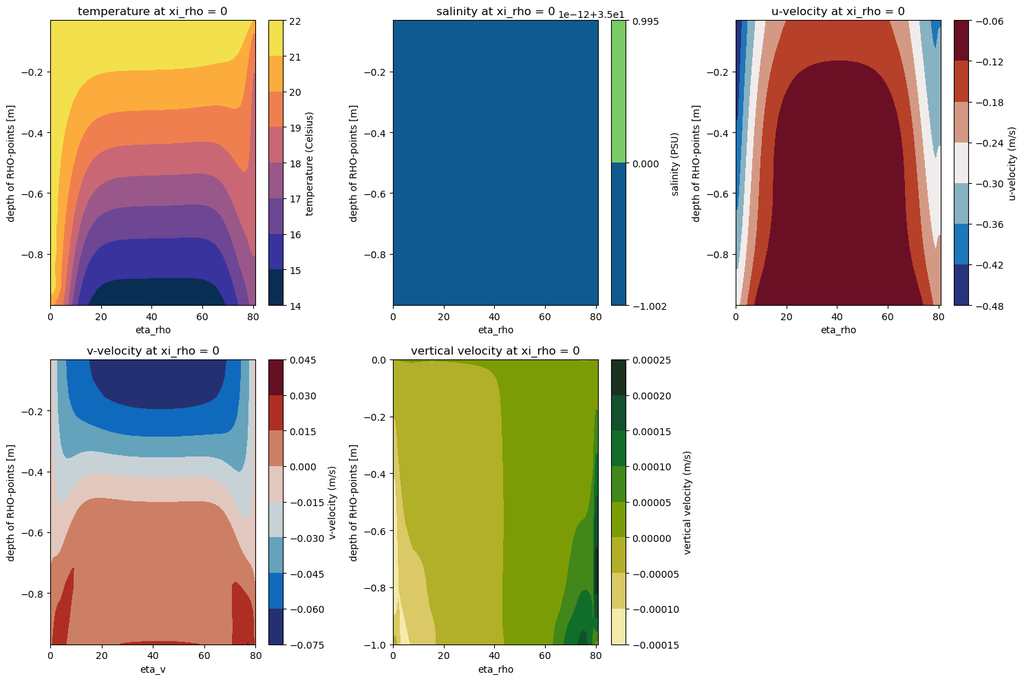

```python
#xi_rho_index  = 0; # Goes from 0 to 42
#time_index    = 0; # Goes from 0 to 20
#time_indices = [0, 10, 20]
# Set fixed indices for ocean_time and xi_rho
xi_rho_index = 0  # Goes from 0 to 42
time_index = 10    # Goes from 0 to 20

# Create the figure with a 2x3 grid layout
fig = plt.figure(figsize=(15.0, 10.0))

# Define each variable and its properties, including the appropriate dimensions for slicing
variables = {
    'temp': {'name': 'temperature', 'units': 'Celsius', 'cmap': cmo.thermal, 'ax': fig.add_subplot(2, 3, 1), 'isel': {'xi_rho': xi_rho_index, 'ocean_time': time_index}},
    'salt': {'name': 'salinity', 'units': 'PSU', 'cmap': cmo.haline, 'ax': fig.add_subplot(2, 3, 2), 'isel': {'xi_rho': xi_rho_index, 'ocean_time': time_index}},
    'u': {'name': 'u-velocity', 'units': 'm/s', 'cmap': cmo.balance, 'ax': fig.add_subplot(2, 3, 3), 'isel': {'xi_u': xi_rho_index, 'ocean_time': time_index}},
    'v': {'name': 'v-velocity', 'units': 'm/s', 'cmap': cmo.balance, 'ax': fig.add_subplot(2, 3, 4), 'isel': {'xi_rho': xi_rho_index, 'ocean_time': time_index}},
    'w': {'name': 'vertical velocity', 'units': 'm/s', 'cmap': cmo.speed, 'ax': fig.add_subplot(2, 3, 5), 'isel': {'xi_rho': xi_rho_index, 'ocean_time': time_index}}
}
# Loop through each variable to plot in its designated subplot
for var, props in variables.items():
    # Select the data with appropriate slicing
    data = his[var].isel(**props['isel'])

    # Determine the x and y coordinates based on the variable's available dimensions
    x_coord = 'eta_rho' if 'eta_rho' in data.dims else 'eta_v' if 'eta_v' in data.dims else None
    y_coord = 's_rho' if 's_rho' in data.dims else 's_w' if 's_w' in data.dims else None

    # Only plot if we have valid x and y coordinates
    if x_coord and y_coord:
        # Plot with contourf in the appropriate subplot
        c = props['ax'].contourf(data[x_coord], data[y_coord], data, cmap=props['cmap'])
        fig.colorbar(c, ax=props['ax'], label=f"{props['name']} ({props['units']})")

        # Set labels and title for each subplot
        props['ax'].set_xlabel(x_coord)
        props['ax'].set_ylabel('depth of RHO-points [m]')
        props['ax'].set_title(f"{props['name']} at xi_rho = {xi_rho_index}")



# Adjust layout to prevent overlapping of subplots
fig.tight_layout()
plt.show()
```

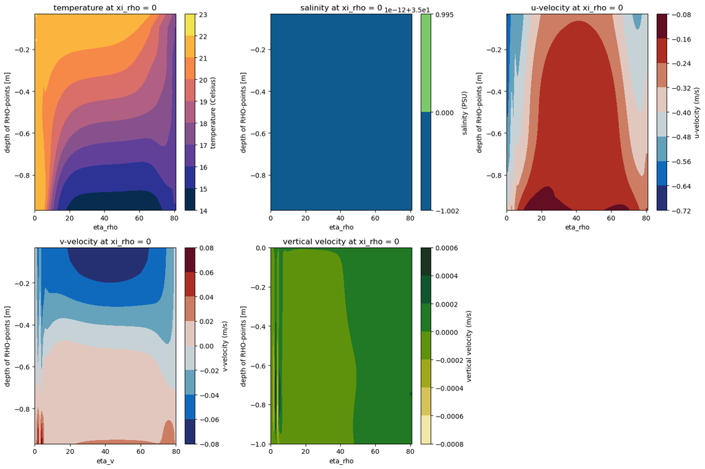

```python
#xi_rho_index  = 0; # Goes from 0 to 42
#time_index    = 0; # Goes from 0 to 20
#time_indices = [0, 10, 20]
# Set fixed indices for ocean_time and xi_rho
xi_rho_index = 0  # Goes from 0 to 42
time_index = 20    # Goes from 0 to 20

# Create the figure with a 2x3 grid layout
fig = plt.figure(figsize=(15.0, 10.0))

# Define each variable and its properties, including the appropriate dimensions for slicing
variables = {
    'temp': {'name': 'temperature', 'units': 'Celsius', 'cmap': cmo.thermal, 'ax': fig.add_subplot(2, 3, 1), 'isel': {'xi_rho': xi_rho_index, 'ocean_time': time_index}},
    'salt': {'name': 'salinity', 'units': 'PSU', 'cmap': cmo.haline, 'ax': fig.add_subplot(2, 3, 2), 'isel': {'xi_rho': xi_rho_index, 'ocean_time': time_index}},
    'u': {'name': 'u-velocity', 'units': 'm/s', 'cmap': cmo.balance, 'ax': fig.add_subplot(2, 3, 3), 'isel': {'xi_u': xi_rho_index, 'ocean_time': time_index}},
    'v': {'name': 'v-velocity', 'units': 'm/s', 'cmap': cmo.balance, 'ax': fig.add_subplot(2, 3, 4), 'isel': {'xi_rho': xi_rho_index, 'ocean_time': time_index}},
    'w': {'name': 'vertical velocity', 'units': 'm/s', 'cmap': cmo.speed, 'ax': fig.add_subplot(2, 3, 5), 'isel': {'xi_rho': xi_rho_index, 'ocean_time': time_index}}
}
# Loop through each variable to plot in its designated subplot
for var, props in variables.items():
    # Select the data with appropriate slicing
    data = his[var].isel(**props['isel'])

    # Determine the x and y coordinates based on the variable's available dimensions
    x_coord = 'eta_rho' if 'eta_rho' in data.dims else 'eta_v' if 'eta_v' in data.dims else None
    y_coord = 's_rho' if 's_rho' in data.dims else 's_w' if 's_w' in data.dims else None

    # Only plot if we have valid x and y coordinates
    if x_coord and y_coord:
        # Plot with contourf in the appropriate subplot
        c = props['ax'].contourf(data[x_coord], data[y_coord], data, cmap=props['cmap'])
        fig.colorbar(c, ax=props['ax'], label=f"{props['name']} ({props['units']})")

        # Set labels and title for each subplot
        props['ax'].set_xlabel(x_coord)
        props['ax'].set_ylabel('depth of RHO-points [m]')
        props['ax'].set_title(f"{props['name']} at xi_rho = {xi_rho_index}")



# Adjust layout to prevent overlapping of subplots
fig.tight_layout()
plt.show()
```

# #3. Explain the differences seen between the first, middle, and last time records for each variable.

The first time record only shows data in the Temrpuature portion of the subplots. The second time record at time_index=10 shows a slight change in the bottom right of the temp plot and noticiable variation in the Velocity plots. Time_index=20 has no change to salinity but differnt patterns for temp and velocities.

# #4. Is there a difference if xi_rho_index=41?

There does not seem to be any changes to the plots output when changing to 41.

# #5. Repeat the plots for the same times, but instead slice along the center of the channel (eta_rho = 40).

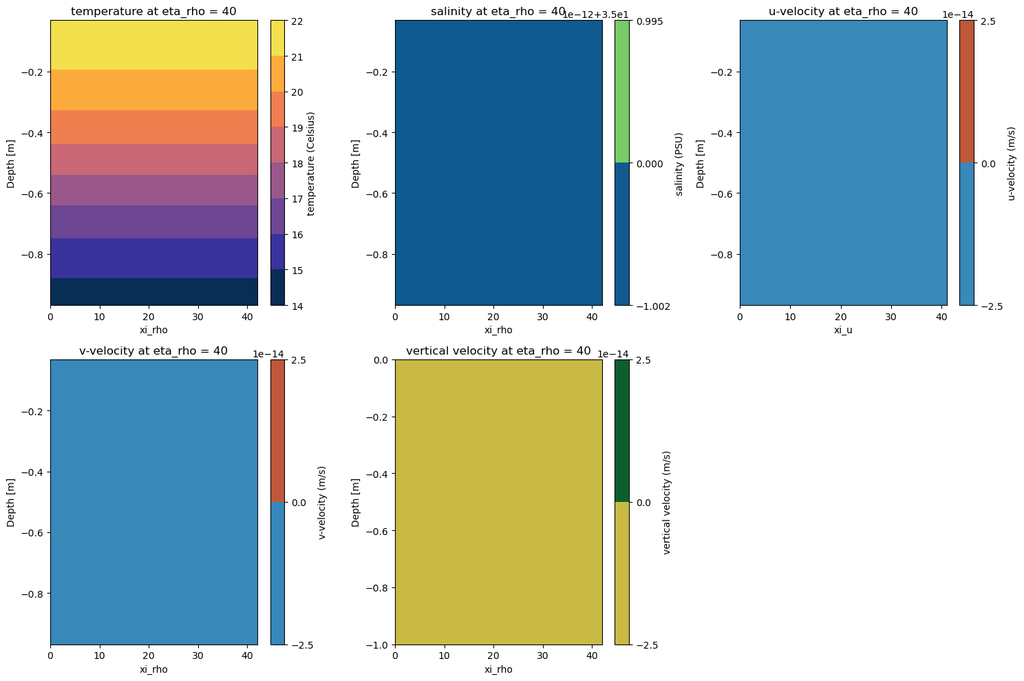

```python
# Set fixed indices for ocean_time and eta_rho
eta_rho_index = 40  # Center of the channel
time_index = 0      # Same time index as before

# Create the figure with a 2x3 grid layout
fig = plt.figure(figsize=(15.0, 10.0))

# Define each variable and its properties, including the appropriate dimensions for slicing
variables = {
    'temp': {
        'name': 'temperature',
        'units': 'Celsius',
        'cmap': cmo.thermal,
        'ax': fig.add_subplot(2, 3, 1),
        'isel': {'eta_rho': eta_rho_index, 'ocean_time': time_index}
    },
    'salt': {
        'name': 'salinity',
        'units': 'PSU',
        'cmap': cmo.haline,
        'ax': fig.add_subplot(2, 3, 2),
        'isel': {'eta_rho': eta_rho_index, 'ocean_time': time_index}
    },
    'u': {
        'name': 'u-velocity',
        'units': 'm/s',
        'cmap': cmo.balance,
        'ax': fig.add_subplot(2, 3, 3),
        'isel': {'eta_rho': eta_rho_index, 'ocean_time': time_index}
    },
    'v': {
        'name': 'v-velocity',
        'units': 'm/s',
        'cmap': cmo.balance,
        'ax': fig.add_subplot(2, 3, 4),
        'isel': {'eta_v': eta_rho_index, 'ocean_time': time_index}
    },
    'w': {
        'name': 'vertical velocity',
        'units': 'm/s',
        'cmap': cmo.speed,
        'ax': fig.add_subplot(2, 3, 5),
        'isel': {'eta_rho': eta_rho_index, 'ocean_time': time_index}
    }
}

# Loop through each variable to plot in its designated subplot
for var, props in variables.items():
    # Select the data with appropriate slicing
    data = his[var].isel(**props['isel'])

    # Determine the x and y coordinates based on the variable's available dimensions
    x_coord = 'xi_rho' if 'xi_rho' in data.dims else 'xi_u' if 'xi_u' in data.dims else None
    y_coord = 's_rho' if 's_rho' in data.dims else 's_w' if 's_w' in data.dims else None

    # Only plot if we have valid x and y coordinates
    if x_coord and y_coord:
        # Plot with contourf in the appropriate subplot
        c = props['ax'].contourf(data[x_coord], data[y_coord], data, cmap=props['cmap'])
        fig.colorbar(c, ax=props['ax'], label=f"{props['name']} ({props['units']})")

        # Set labels and title for each subplot
        props['ax'].set_xlabel(x_coord)
        props['ax'].set_ylabel('Depth [m]')
        props['ax'].set_title(f"{props['name']} at eta_rho = {eta_rho_index}")


# Adjust layout to prevent overlapping of subplots
fig.tight_layout()
plt.show()
```

[figure not shown]

```python
# Set fixed indices for ocean_time and eta_rho
eta_rho_index = 40  # Center of the channel
time_index = 10      # Same time index as before

# Create the figure with a 2x3 grid layout
fig = plt.figure(figsize=(15.0, 10.0))

# Define each variable and its properties, including the appropriate dimensions for slicing
variables = {
    'temp': {
        'name': 'temperature',
        'units': 'Celsius',
        'cmap': cmo.thermal,
        'ax': fig.add_subplot(2, 3, 1),
        'isel': {'eta_rho': eta_rho_index, 'ocean_time': time_index}
    },
    'salt': {
        'name': 'salinity',
        'units': 'PSU',
        'cmap': cmo.haline,
        'ax': fig.add_subplot(2, 3, 2),
        'isel': {'eta_rho': eta_rho_index, 'ocean_time': time_index}
    },
    'u': {
        'name': 'u-velocity',
        'units': 'm/s',
        'cmap': cmo.balance,
        'ax': fig.add_subplot(2, 3, 3),
        'isel': {'eta_rho': eta_rho_index, 'ocean_time': time_index}
    },
    'v': {
        'name': 'v-velocity',
        'units': 'm/s',
        'cmap': cmo.balance,
        'ax': fig.add_subplot(2, 3, 4),
        'isel': {'eta_v': eta_rho_index, 'ocean_time': time_index}
    },
    'w': {
        'name': 'vertical velocity',
        'units': 'm/s',
        'cmap': cmo.speed,
        'ax': fig.add_subplot(2, 3, 5),
        'isel': {'eta_rho': eta_rho_index, 'ocean_time': time_index}
    }
}

# Loop through each variable to plot in its designated subplot
for var, props in variables.items():
    # Select the data with appropriate slicing
    data = his[var].isel(**props['isel'])

    # Determine the x and y coordinates based on the variable's available dimensions
    x_coord = 'xi_rho' if 'xi_rho' in data.dims else 'xi_u' if 'xi_u' in data.dims else None
    y_coord = 's_rho' if 's_rho' in data.dims else 's_w' if 's_w' in data.dims else None

    # Only plot if we have valid x and y coordinates
    if x_coord and y_coord:
        # Plot with contourf in the appropriate subplot
        c = props['ax'].contourf(data[x_coord], data[y_coord], data, cmap=props['cmap'])
        fig.colorbar(c, ax=props['ax'], label=f"{props['name']} ({props['units']})")

        # Set labels and title for each subplot
        props['ax'].set_xlabel(x_coord)
        props['ax'].set_ylabel('Depth [m]')
        props['ax'].set_title(f"{props['name']} at eta_rho = {eta_rho_index}")

        # Flip the y-axis so depth increases downward
        #props['ax'].invert_yaxis()

# Adjust layout to prevent overlapping of subplots
fig.tight_layout()
plt.show()
```

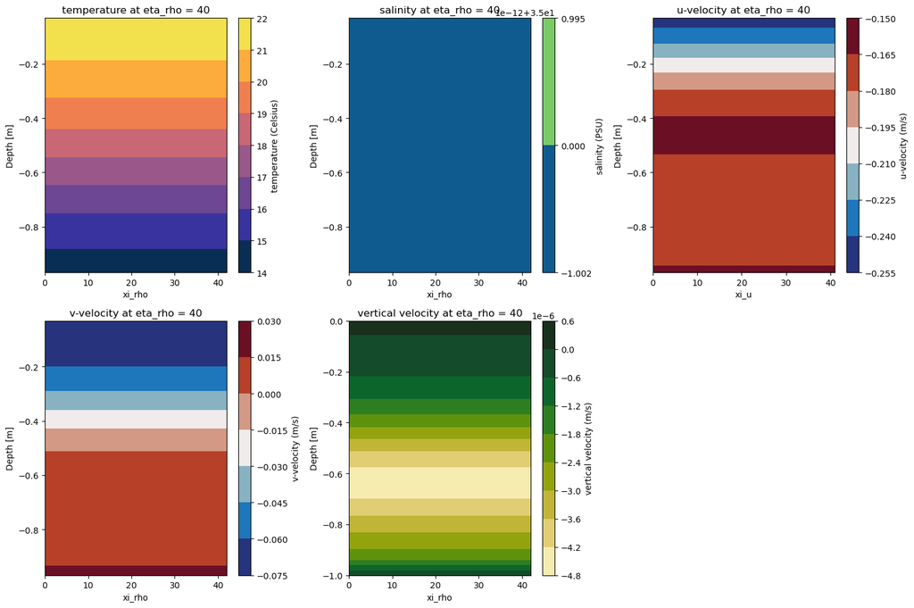

```python
# Set fixed indices for ocean_time and eta_rho
eta_rho_index = 40  # Center of the channel
time_index = 20      # Same time index as before

# Create the figure with a 2x3 grid layout
fig = plt.figure(figsize=(15.0, 10.0))

# Define each variable and its properties, including the appropriate dimensions for slicing
variables = {
    'temp': {
        'name': 'temperature',
        'units': 'Celsius',
        'cmap': cmo.thermal,
        'ax': fig.add_subplot(2, 3, 1),
        'isel': {'eta_rho': eta_rho_index, 'ocean_time': time_index}
    },
    'salt': {
        'name': 'salinity',
        'units': 'PSU',
        'cmap': cmo.haline,
        'ax': fig.add_subplot(2, 3, 2),
        'isel': {'eta_rho': eta_rho_index, 'ocean_time': time_index}
    },
    'u': {
        'name': 'u-velocity',
        'units': 'm/s',
        'cmap': cmo.balance,
        'ax': fig.add_subplot(2, 3, 3),
        'isel': {'eta_rho': eta_rho_index, 'ocean_time': time_index}
    },
    'v': {
        'name': 'v-velocity',
        'units': 'm/s',
        'cmap': cmo.balance,
        'ax': fig.add_subplot(2, 3, 4),
        'isel': {'eta_v': eta_rho_index, 'ocean_time': time_index}
    },
    'w': {
        'name': 'vertical velocity',
        'units': 'm/s',
        'cmap': cmo.speed,
        'ax': fig.add_subplot(2, 3, 5),
        'isel': {'eta_rho': eta_rho_index, 'ocean_time': time_index}
    }
}

# Loop through each variable to plot in its designated subplot
for var, props in variables.items():
    # Select the data with appropriate slicing
    data = his[var].isel(**props['isel'])

    # Determine the x and y coordinates based on the variable's available dimensions
    x_coord = 'xi_rho' if 'xi_rho' in data.dims else 'xi_u' if 'xi_u' in data.dims else None
    y_coord = 's_rho' if 's_rho' in data.dims else 's_w' if 's_w' in data.dims else None

    # Only plot if we have valid x and y coordinates
    if x_coord and y_coord:
        # Plot with contourf in the appropriate subplot
        c = props['ax'].contourf(data[x_coord], data[y_coord], data, cmap=props['cmap'])
        fig.colorbar(c, ax=props['ax'], label=f"{props['name']} ({props['units']})")

        # Set labels and title for each subplot
        props['ax'].set_xlabel(x_coord)
        props['ax'].set_ylabel('Depth [m]')
        props['ax'].set_title(f"{props['name']} at eta_rho = {eta_rho_index}")

        # Flip the y-axis so depth increases downward
        #props['ax'].invert_yaxis()

# Adjust layout to prevent overlapping of subplots
fig.tight_layout()
plt.show()
```

# #6. What differences do you see over time, and for the overall structure of the upwelling setup?

This change shows a more uniform level with time and individual rows at depth. The values are similar to the first orientation.

# #7. What differences do you see when you look at the output in the average, diagnostic, and restart file? What purposes do these 4 output files serve and why do they differ?

Average= averages over longer time scales, allows for a broader view with smoother images from data. Diagnostic: derived variables used for additional modeling. Restart: contains peramiters for variables allowing to restart models. 3 of the files offers a different data set to work with and can produce models of varying resolutions. Some can be used to give truth to other models.